# Predicting WHO Life expectancies

## Phase 2: Statistical Modelling

#### Group Name: Project Group 137

#### Name(s) & ID(s) of Group Members: Steven Nguyen, s3874130

### #

- Introduction
- Statistical Modelling
- Critique & Limitations
- Summary & Conclusions

## Introduction

### Phase 1 Summary

In the Phase 1 report, our goal was to identify which categorical variables in the dataset that had the most impact on our predictive model. In this case, it was to determine the life expectancies of people around the world based on their environmental factors such as their country's obesity rate, regions they live in, bmi levels etc. In order to visualise this, we first had to preprocess our data and cleanse it to remove any variables that were irrelevant to the model. This consisted of dropping variables of `NaN` type which was the most practical approach. However it was discovered that after imputing all rows that contained `NaN` values, we ended up with 2 rows in total with the dataset. This resulted in an impractical dataset, so therefore after analysing the original dataset, we came to a conclusion to remove columns we assumed were irrelevant. This was based on counting how many `NaN` values those columns contained, so logically columns with `NaN` values more than 3 digits were dropped as they contained little to no data. In this way, we decided to rely more on logic rather than speculation, optimising columns we deemed 'unecessary' to provide a more accurate dataset to work with.

After the data preprocessing stage, the next part of the first phase was to visualise and explore the data to grasp a further understanding of our main objective. This consisted of plotting different types of graphs and analysing them to provide explanations of correlations between variables. In doing so, some of our speculations and predictions proved to be incorrect based off the data provided in the plots. Hence, this is why visualisation is important as we assumed that there would be a linear correlation between high bmi and low life expectancy but that was proven false based on some of the scatter plots provided in the three-variable plots.

### Report Overview

In this report, we will be producing a statistical model. This consists of a full model by fitting a multiple linear regression for the variable `life_expect` using our cleansed dataset produced in the first phase. After doing so, we must perform a full model diagnostic check to make sure our model is consistent and does not impede any regression assumptions. When this stage has been completed, we need to run a backwards feature selection using p-values to determine which features are irrelevant to our dependent variable in predicting our life expectancies.

### Overview of Methodology

The methodology will consist of a full model. As we do not have many independent variables, we will be manually adding all the independent variables to our construct our regression formula. In this way, we are able to use the `Statsmodels` module to produce a statistical model formula. As a result of this, we are able to encode our data into an OLS model. After doing so, we will use the R-squared value to determine the variance and the p-values to determine which variables are significant for our predictive model.

#### Module Imports

```python
import numpy as np
import pandas as pd
import matplotlib.pyplot as plt
import seaborn as sns
import statsmodels.api as sm
import statsmodels.formula.api as smf
import patsy

import warnings
warnings.filterwarnings('ignore')

pd.set_option('display.max_columns', None)

%matplotlib inline
%config InlineBackend.figure_format = 'retina'
plt.style.use("ggplot")

df = pd.read_csv('Phase2_group137.csv')
```

## Statistical Modelling

### Full model

To begin, we are going to fit a multiple linear regression model which is going to predict our variable `life_expect`. Here is the clean data produced from Phase 1.

```python
df = df.drop(columns='Unnamed: 0')
df.head()
```

|  | country | region | year | life_expect | life_exp60 | adult_mortality | infant_mort | ages_1_to_4_mort | alcohol | bmi | age_1_to_5_thiness | age_5_to_19_obesity | measles | polio | diphtheria | basic_water | une_pop | une_infant | une_life |
| --- | --- | --- | --- | --- | --- | --- | --- | --- | --- | --- | --- | --- | --- | --- | --- | --- | --- | --- | --- |
| 0 | Australia | Western Pacific | 2005 | 80.96873 | 24.03159 | 68.12927 | 0.004690 | 0.000225 | 10.30000 | 26.7 | 0.7 | 10.6 | 94.0 | 92.0 | 92.0 | 99.77814 | 20178.540 | 4.8 | 80.84146 |
| 1 | Kenya | Africa | 2005 | 55.22525 | 16.72654 | 437.66490 | 0.055615 | 0.007855 | 0.87938 | 22.4 | 8.7 | 0.8 | 69.0 | 70.0 | 76.0 | 50.90902 | 36624.895 | 49.6 | 54.73200 |
| 2 | Thailand | South-East Asia | 2001 | 70.91342 | 20.40177 | 200.51060 | 0.019370 | 0.000820 | 5.84362 | 23.0 | 9.5 | 3.4 | 94.0 | 97.0 | 96.0 | 94.07426 | 63539.196 | 17.7 | 70.83200 |
| 3 | United Kingdom of Great Britain and Northern I... | Europe | 2014 | 81.42310 | 24.30686 | 68.06020 | 0.003860 | 0.000170 | 9.45024 | 27.1 | 0.7 | 10.1 | 93.0 | 95.0 | 95.0 | 100.00000 | 65423.047 | 3.9 | 81.30488 |
| 4 | Armenia | Europe | 2011 | 73.59209 | 19.14928 | 135.21890 | 0.015555 | 0.000505 | 4.07280 | 26.1 | 2.0 | 3.7 | 97.0 | 96.0 | 95.0 | 98.59529 | 2876.538 | 15.7 | 73.57200 |

```python
categoricalColumns = df.columns[df.dtypes==object].tolist()


for col in categoricalColumns:
    df[col] = df[col].str.strip()
    df[col] = df[col].str.replace("CÃ´te_d_Ivoire", "Ca_te_d_Ivoire")
    df[col] = df[col].str.replace('-', '_')
    df[col] = df[col].str.replace(' ', '_')
    df[col] = df[col].str.replace("'", '_')
    df[col] = df[col].str.replace('(', '_')
    df[col] = df[col].str.replace(')', '_')



for col in categoricalColumns:
    print('Unique values for ' + col)
    print(df[col].unique())
    print('')
```

```
Unique values for country
['Australia' 'Kenya' 'Thailand'
 'United_Kingdom_of_Great_Britain_and_Northern_Ireland' 'Armenia'
 'Albania' 'Djibouti' 'Mongolia' 'India' 'Mexico' 'Congo' 'Guinea' 'Togo'
 'Tunisia' 'Azerbaijan' 'Samoa' 'Turkey' 'Colombia' 'Viet_Nam'
 'Costa_Rica' 'Nepal' 'Cambodia' 'Saint_Lucia' 'Denmark' 'Bhutan' 'Cuba'
 'Pakistan' 'New_Zealand' 'Democratic_People_s_Republic_of_Korea'
 'Belgium' 'Uzbekistan' 'Republic_of_Korea' 'Seychelles'
 'Republic_of_North_Macedonia' 'France' 'Kuwait' 'Mauritania' 'Jordan'
 'Kazakhstan' 'Qatar' 'Micronesia__Federated_States_of_' 'Hungary'
 'Eritrea' 'Saudi_Arabia' 'Benin' 'South_Africa' 'Cabo_Verde'
 'Antigua_and_Barbuda' 'Lithuania' 'Argentina' 'Zambia' 'Yemen' 'Greece'
 'Malaysia' 'Cameroon' 'Zimbabwe' 'Ireland' 'United_Republic_of_Tanzania'
 'Panama' 'Bahamas' 'Croatia' 'China' 'Trinidad_and_Tobago' 'Belarus'
 'Papua_New_Guinea' 'Slovenia' 'Niger'
 'Venezuela__Bolivarian_Republic_of_' 'Netherlands' 'Jamaica' 'Gabon'
 'Botswana' 'Morocco' 'Syrian_Arab_Republic' 'Norway' 'Malta' 'Nicaragua'
 'Slovakia' 'Kyrgyzstan' 'Georgia' 'Suriname' 'Burkina_Faso' 'Tajikistan'
 'Grenada' 'Comoros' 'Eswatini' 'Lebanon' 'Guinea_Bissau' 'Philippines'
 'Iraq' 'Sierra_Leone' 'Myanmar' 'Turkmenistan' 'Madagascar' 'Uruguay'
 'Iran__Islamic_Republic_of_' 'Lao_People_s_Democratic_Republic' 'Egypt'
 'Brunei_Darussalam' 'Bolivia__Plurinational_State_of_' 'Timor_Leste'
 'Bahrain' 'Sao_Tome_and_Principe' 'Somalia' 'Russian_Federation'
 'United_States_of_America' 'Oman' 'Belize' 'Chile' 'Canada' 'El_Salvador'
 'Equatorial_Guinea' 'Ecuador' 'Estonia' 'Israel' 'Peru' 'Solomon_Islands'
 'Kiribati' 'Paraguay' 'Japan' 'Mozambique' 'Bulgaria'
 'Saint_Vincent_and_the_Grenadines' 'Dominican_Republic' 'Austria'
 'Poland' 'Democratic_Republic_of_the_Congo' 'Algeria' 'Liberia'
 'Honduras' 'United_Arab_Emirates' 'Central_African_Republic' 'Guatemala'
 'Malawi' 'Sweden' 'Ukraine' 'Barbados' 'Rwanda' 'Republic_of_Moldova'
 'Tonga' 'Romania' 'Nigeria' 'Libya' 'Italy' 'Mauritius' 'Iceland'
 'Finland' 'Namibia' 'Portugal' 'Luxembourg' 'Angola' 'Maldives' 'Serbia'
 'Mali' 'Lesotho' 'Bangladesh' 'Latvia' 'Cyprus' 'CÃ´te_d_Ivoire' 'Spain'
 'Czechia' 'Indonesia' 'Germany' 'Vanuatu' 'Senegal' 'Ghana' 'Sri_Lanka'
 'Brazil' 'Bosnia_and_Herzegovina' 'Burundi' 'Haiti' 'Switzerland'
 'Uganda' 'Fiji' 'Gambia' 'Chad' 'Afghanistan' 'Montenegro' 'Ethiopia'
 'Singapore' 'Guyana']

Unique values for region
['Western_Pacific' 'Africa' 'South_East_Asia' 'Europe'
 'Eastern_Mediterranean' 'Americas']
```

```python
for col in categoricalColumns:
    df[col] = df[col].str.strip()
    df[col] = df[col].str.replace("CÃ´te_d_Ivoire", "Ca_te_d_Ivoire")
    df[col] = df[col].str.replace('-', '_')
    df[col] = df[col].str.replace(' ', '_')
    df[col] = df[col].str.replace("'", '_')
    df[col] = df[col].str.replace('(', '_')
    df[col] = df[col].str.replace(')', '_')
```

We are going to write the formula by concatenating all the columns into a `String` type except for the `life_expect` as this is our dependent variable.

```python
indep_vars_formula = ' + '.join(df.drop(columns='life_expect').columns)
formula_str = 'life_expect ~ ' + indep_vars_formula
display(formula_str)
```

```
'life_expect ~ country + region + year + life_exp60 + adult_mortality + infant_mort + ages_1_to_4_mort + alcohol + bmi + age_1_to_5_thiness + age_5_to_19_obesity + measles + polio + diphtheria + basic_water + une_pop + une_infant + une_life'
```

We know that from the `Statsmodels` module, we are not able to automatically select variables with this formula. In order to resolve this issue, we must utilise the `get_dummies()` function from `pandas` module for one-hot-encoding of categorical variables. As a result of this, we are able to produce a new string formula with encoded features.

```python
df_encoded = pd.get_dummies(df, drop_first=True)
df_encoded.head()
```

|  | year | life_expect | life_exp60 | adult_mortality | infant_mort | ages_1_to_4_mort | alcohol | bmi | age_1_to_5_thiness | age_5_to_19_obesity | measles | polio | diphtheria | basic_water | une_pop | une_infant | une_life | country_Albania | country_Algeria | country_Angola | country_Antigua_and_Barbuda | country_Argentina | country_Armenia | country_Australia | country_Austria | country_Azerbaijan | country_Bahamas | country_Bahrain | country_Bangladesh | … |
| --- | --- | --- | --- | --- | --- | --- | --- | --- | --- | --- | --- | --- | --- | --- | --- | --- | --- | --- | --- | --- | --- | --- | --- | --- | --- | --- | --- | --- | --- | --- |
| 0 | 2005 | 80.96873 | 24.03159 | 68.12927 | 0.004690 | 0.000225 | 10.30000 | 26.7 | 0.7 | 10.6 | 94.0 | 92.0 | 92.0 | 99.77814 | 20178.540 | 4.8 | 80.84146 | 0 | 0 | 0 | 0 | 0 | 0 | 1 | 0 | 0 | 0 | 0 | 0 | … |
| 1 | 2005 | 55.22525 | 16.72654 | 437.66490 | 0.055615 | 0.007855 | 0.87938 | 22.4 | 8.7 | 0.8 | 69.0 | 70.0 | 76.0 | 50.90902 | 36624.895 | 49.6 | 54.73200 | 0 | 0 | 0 | 0 | 0 | 0 | 0 | 0 | 0 | 0 | 0 | 0 | … |
| 2 | 2001 | 70.91342 | 20.40177 | 200.51060 | 0.019370 | 0.000820 | 5.84362 | 23.0 | 9.5 | 3.4 | 94.0 | 97.0 | 96.0 | 94.07426 | 63539.196 | 17.7 | 70.83200 | 0 | 0 | 0 | 0 | 0 | 0 | 0 | 0 | 0 | 0 | 0 | 0 | … |
| 3 | 2014 | 81.42310 | 24.30686 | 68.06020 | 0.003860 | 0.000170 | 9.45024 | 27.1 | 0.7 | 10.1 | 93.0 | 95.0 | 95.0 | 100.00000 | 65423.047 | 3.9 | 81.30488 | 0 | 0 | 0 | 0 | 0 | 0 | 0 | 0 | 0 | 0 | 0 | 0 | … |
| 4 | 2011 | 73.59209 | 19.14928 | 135.21890 | 0.015555 | 0.000505 | 4.07280 | 26.1 | 2.0 | 3.7 | 97.0 | 96.0 | 95.0 | 98.59529 | 2876.538 | 15.7 | 73.57200 | 0 | 0 | 0 | 0 | 0 | 1 | 0 | 0 | 0 | 0 | 0 | 0 | … |

```python
df_encoded.head().shape
```

```
(5, 202)
```

After one-hot-encoding this we are able to produce more columns with numerical values of either `0` or `1` which enables us to determine p-values. This will be seen in the Ordinary Least Squares table in the upcoming section.

```python
indep_vars_formula_encoded = ' + '.join(df_encoded.drop(columns='life_expect').columns)
formula_str_encoded = 'life_expect ~ ' + indep_vars_formula_encoded
display(formula_str_encoded)
```

```
'life_expect ~ year + life_exp60 + adult_mortality + infant_mort + ages_1_to_4_mort + alcohol + bmi + age_1_to_5_thiness + age_5_to_19_obesity + measles + polio + diphtheria + basic_water + une_pop + une_infant + une_life + country_Albania + country_Algeria + country_Angola + country_Antigua_and_Bar…
```

We have now defined the encoded formula for our OLS model. This is defined as a very large string in the above cell, so now we need to input all the parameters into the `Statsmodels` module.

```python
full_model = sm.formula.ols(formula=formula_str_encoded, data=df_encoded)
print(full_model.fit().summary())
print(f'\nR-squared value: {full_model.fit().rsquared}.')
```

```
                            OLS Regression Results
==============================================================================
Dep. Variable:            life_expect   R-squared:                       0.999
Model:                            OLS   Adj. R-squared:                  0.999
Method:                 Least Squares   F-statistic:                 2.651e+04
Date:                Sun, 23 Oct 2022   Prob (F-statistic):               0.00
Time:                        23:52:30   Log-Likelihood:                 402.59
No. Observations:                3000   AIC:                            -411.2
Df Residuals:                    2803   BIC:                             772.1
Df Model:                         196
Covariance Type:            nonrobust
================================================================================================================================
                                                                   coef    std err          t      P>|t|      [0.025      0.975]
--------------------------------------------------------------------------------------------------------------------------------
Intercept                                                       17.3326      5.838      2.969      0.003       5.885      28.781
year                                                             0.0222      0.003      6.871      0.000       0.016       0.029
life_exp60                                                       0.8149      0.012     65.391      0.000       0.790       0.839
adult_mortality                                                 -0.0366      0.000   -139.443      0.000      -0.037      -0.036
infant_mort                                                    -46.6755      2.440    -19.130      0.000     -51.460     -41.891
ages_1_to_4_mort                                              -174.0136      5.303    -32.812      0.000    -184.413    -163.615
alcohol                                                          0.0003      0.005      0.062      0.951      -0.010       0.010
bmi                                                             -0.0102      0.028     -0.359      0.720      -0.066       0.045
age_1_to_5_thiness                                               0.0362      0.009      3.944      0.000       0.018       0.054
age_5_to_19_obesity                                             -0.0221      0.006     -3.800      0.000      -0.033      -0.011
measles                                                          0.0029      0.001      2.934      0.003       0.001       0.005
polio                                                        -1.889e-05      0.001     -0.014      0.989      -0.003       0.003
diphtheria                                                       0.0046      0.001      3.495      0.000       0.002       0.007
basic_water                                                      0.0100      0.002      5.927      0.000       0.007       0.013
une_pop                                                       1.241e-06   5.68e-07      2.187      0.029    1.28e-07    2.35e-06
une_infant                                                      -0.0112      0.003     -3.964      0.000      -0.017      -0.006
une_life                                                        -0.0205      0.007     -3.021      0.003      -0.034      -0.007
country_Albania                                                 -0.7512      0.062    -12.150      0.000      -0.872      -0.630
country_Algeria                                                  1.3509      0.077     17.603      0.000       1.200       1.501
country_Angola                                                  -0.4237      0.155     -2.736      0.006      -0.727      -0.120
country_Antigua_and_Barbuda                                      0.3460      0.063      5.502      0.000       0.223       0.469
country_Argentina                                                0.5015      0.062      8.045      0.000       0.379       0.624
country_Armenia                                                 -0.2729      0.068     -3.994      0.000      -0.407      -0.139
country_Australia                                                0.9780      0.118      8.313      0.000       0.747       1.209
country_Austria                                                  0.3724      0.071      5.212      0.000       0.232       0.513
country_Azerbaijan                                              -0.6693      0.092     -7.273      0.000      -0.850      -0.489
```

[output cut: 174 more lines]

```
region_South_East_Asia                                           0.4817      0.143      3.366      0.001       0.201       0.762
region_Western_Pacific                                           1.7394      0.056     31.104      0.000       1.630       1.849
==============================================================================
Omnibus:                     2178.041   Durbin-Watson:                   1.980
Prob(Omnibus):                  0.000   Jarque-Bera (JB):           241114.504
Skew:                          -2.639   Prob(JB):                         0.00
Kurtosis:                      46.601   Cond. No.                     3.28e+21
==============================================================================

Notes:
[1] Standard Errors assume that the covariance matrix of the errors is correctly specified.
[2] The smallest eigenvalue is 5.79e-30. This might indicate that there are
strong multicollinearity problems or that the design matrix is singular.

R-squared value: 0.9994608297139352.
```

By observing the p-values from the above table, we are able to recognise that most of the values fall under 0.05 meaning that they are highly significant.

Now that we have created our regression model, it is now time to compare the actual life expectancy vs the predicted life expectancy models and residuals for the full model. The result is shown on the table below.

```python
full_residuals = pd.DataFrame({'actual': df_encoded['life_expect'], 'predicted': full_model.fit().fittedvalues, 'residual': full_model.fit().resid})
full_residuals.head(10)
```

|  | actual | predicted | residual |
| --- | --- | --- | --- |
| 0 | 80.96873 | 81.001332 | -0.032602 |
| 1 | 55.22525 | 55.108983 | 0.116267 |
| 2 | 70.91342 | 71.277632 | -0.364212 |
| 3 | 81.42310 | 81.393167 | 0.029933 |
| 4 | 73.59209 | 73.643499 | -0.051409 |
| 5 | 74.06049 | 74.113574 | -0.053084 |
| 6 | 58.01141 | 58.246365 | -0.234955 |
| 7 | 69.64532 | 69.659430 | -0.014110 |
| 8 | 68.82572 | 68.891756 | -0.066036 |
| 9 | 75.01183 | 74.956807 | 0.055023 |

We can now visualise our data by plotting this on a scatterplot with the regression line (R).

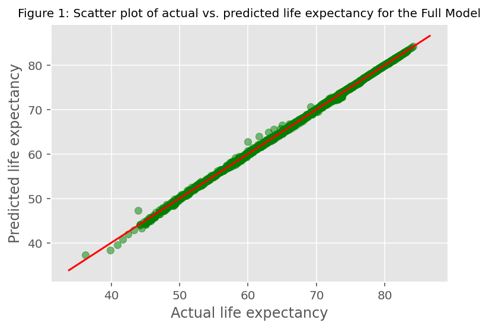

```python
def plot_line(axis, slope, intercept, **kargs):
    xmin, xmax = axis.get_xlim()
    plt.plot([xmin, xmax], [xmin*slope+intercept, xmax*slope+intercept], **kargs)

plt.scatter(full_residuals['actual'], full_residuals['predicted'], alpha=0.5, color="green")
plot_line(axis=plt.gca(), slope=1, intercept=0, c="red")
plt.xlabel('Actual life expectancy')
plt.ylabel('Predicted life expectancy')
plt.title('Figure 1: Scatter plot of actual vs. predicted life expectancy for the Full Model', fontsize=10)
plt.show()
```

From the data seen above, it is seen that the life expectancy predicted is practically always the same as the actual life expectancy. Hence, this is why the scatterplot values are clumped on top of the regression line. The next stage of this report is to check whether or not the plot complies with the regression assumptions.

### Full Model Diagnostic Checks

The main purpose of this is to check whether there are violations of the regression assumptions which are listed below:

1. linearity of the relationship between target feature and independent features
2. constant variance of the residuals (Homoscedasticity, avoid heteroscedasticity)
3. residuals are normally distributed
4. statistical independence of the residuals

The first step is to draw up a plot of the Residuals vs Predicted life expectancy.

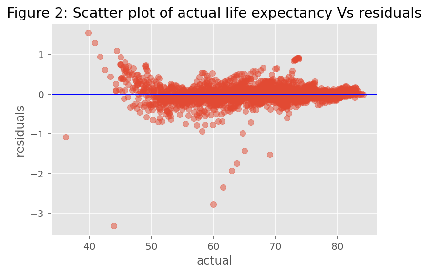

```python
actual = df['life_expect']
predicted = full_model.fit().fittedvalues
residuals = full_model.fit().resid
plt.scatter(actual, residuals, alpha=0.5)
plt.axhline(0, c='blue')
plt.xlabel("actual")
plt.ylabel("residuals")
plt.title("Figure 2: Scatter plot of actual life expectancy Vs residuals")
plt.show()
```

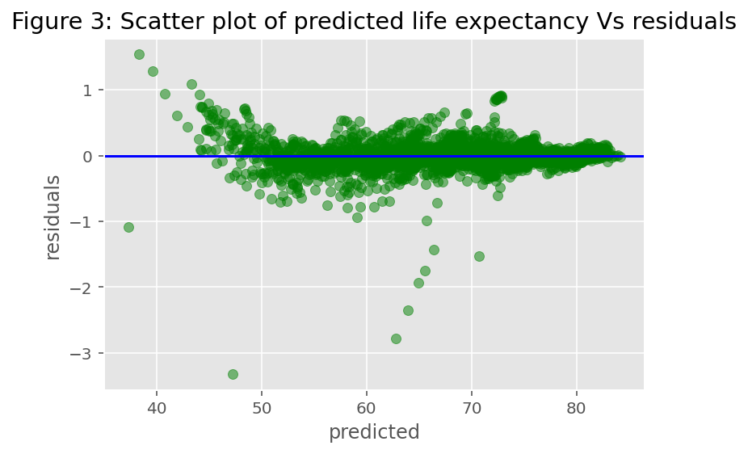

```python
plt.scatter(predicted, residuals, alpha=0.5, c='green')
plt.axhline(0, c='blue')
plt.xlabel("predicted")
plt.ylabel("residuals")
plt.title("Figure 3: Scatter plot of predicted life expectancy Vs residuals")
plt.show()
```

Figure 2 and 3 are almost identical. This shows that the variables used were extremely accurate. In this case, most of the points are located both above and under the line. These graphs are ideal you would want a model that has a mean of around 0.

```python
from scipy.stats import probplot
```

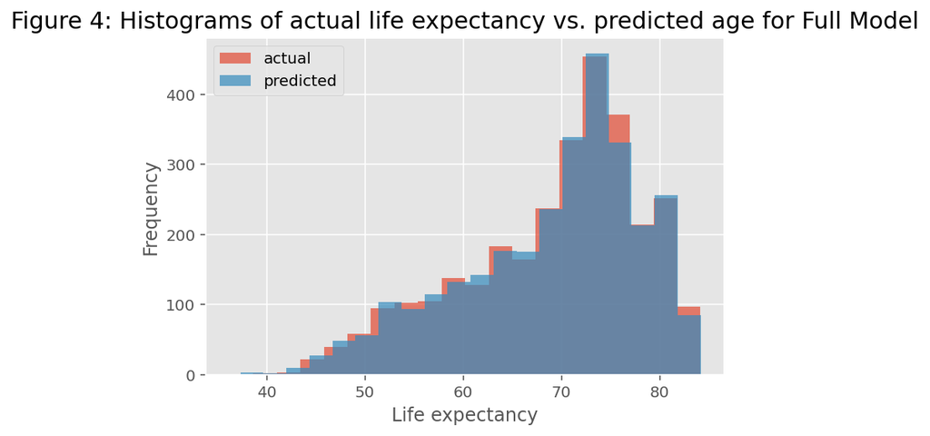

```python
plt.hist(full_residuals['actual'], label='actual', bins=20, alpha=0.7);
plt.hist(full_residuals['predicted'], label='predicted', bins=20, alpha=0.7);
plt.xlabel('Life expectancy');
plt.ylabel('Frequency');
plt.title('Figure 4: Histograms of actual life expectancy vs. predicted age for Full Model', fontsize=15);
plt.legend()
plt.show();
```

We can observe that the distributions are particularly similar. The model's predictions are extremely similar to the actual data. This could mean that the dataset given to us was very accurate in performing life expectancy calculations based off the variables they have thought of.

We can also check the histogram of the residuals for the full model.

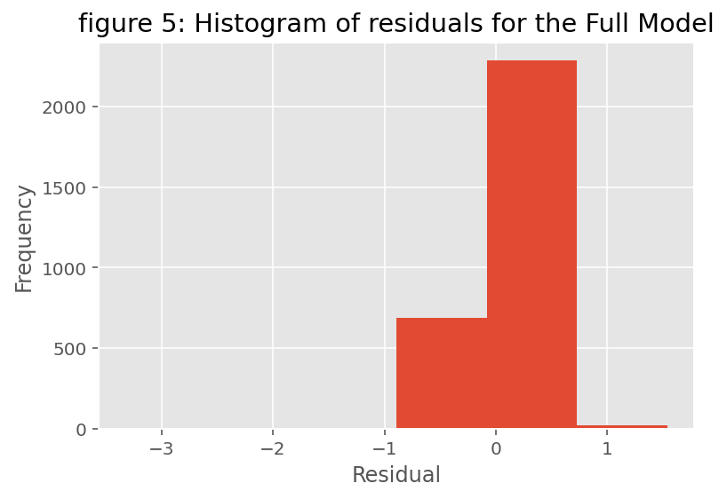

```python
plt.hist(residuals, bins=6)
plt.title("figure 5: Histogram of residuals for the Full Model")
plt.xlabel('Residual')
plt.ylabel('Frequency')
plt.show()
```

### Backwards Feature Selection

The next stage of this diagnostic check is to perform some sort of backward feature selection by utilising the p-values. As `Statsmodels` does not contain this feature, we have borrowed the code of 'David Akman', RMIT Professor of Mathematics of Computing 2 (MATH2412).

```python
## create the patsy model description from formula
patsy_description = patsy.ModelDesc.from_formula(formula_str_encoded)

# initialize feature-selected fit to full model
linreg_fit = full_model.fit()

# do backwards elimination using p-values
p_val_cutoff = 0.05

## WARNING 1: The code below assumes that the Intercept term is present in the model.
## WARNING 2: It will work only with main effects and two-way interactions, if any.

print('\nPerforming backwards feature selection using p-values:')

while True:

    # uncomment the line below if you would like to see the regression summary
    # in each step:
    ### print(linreg_fit.summary())

    pval_series = linreg_fit.pvalues.drop(labels='Intercept')
    pval_series = pval_series.sort_values(ascending=False)
    term = pval_series.index[0]
    pval = pval_series[0]
    if (pval < p_val_cutoff):
        break
    term_components = term.split(':')
    print(f'\nRemoving term "{term}" with p-value {pval:.4}')
    if (len(term_components) == 1): ## this is a main effect term
        patsy_description.rhs_termlist.remove(patsy.Term([patsy.EvalFactor(term_components[0])]))
    else: ## this is an interaction term
        patsy_description.rhs_termlist.remove(patsy.Term([patsy.EvalFactor(term_components[0]),
                                                        patsy.EvalFactor(term_components[1])]))

    linreg_fit = smf.ols(formula=patsy_description, data=df_encoded).fit()

###
## this is the clean fit after backwards elimination
model_reduced_fitted = smf.ols(formula = patsy_description, data = df_encoded).fit()
###

#########
print("\n***")
print(model_reduced_fitted.summary())
print("***")
print(f"Regression number of terms: {len(model_reduced_fitted.model.exog_names)}")
print(f"Regression F-distribution p-value: {model_reduced_fitted.f_pvalue:.4f}")
print(f"Regression R-squared: {model_reduced_fitted.rsquared:.4f}")
print(f"Regression Adjusted R-squared: {model_reduced_fitted.rsquared_adj:.4f}")
```

```
Performing backwards feature selection using p-values:

Removing term "polio" with p-value 0.9887

Removing term "country_Bulgaria" with p-value 0.9778

Removing term "alcohol" with p-value 0.9513

Removing term "country_Liberia" with p-value 0.9131

Removing term "country_Kenya" with p-value 0.8331

Removing term "country_Mozambique" with p-value 0.8259

Removing term "country_Nepal" with p-value 0.7871

Removing term "country_Estonia" with p-value 0.752

Removing term "country_Montenegro" with p-value 0.8287

Removing term "country_Panama" with p-value 0.765

Removing term "bmi" with p-value 0.6578

Removing term "country_Lithuania" with p-value 0.6224

Removing term "country_Latvia" with p-value 0.6582

Removing term "country_Peru" with p-value 0.5521

Removing term "country_Myanmar" with p-value 0.4856

Removing term "country_Brunei_Darussalam" with p-value 0.5177

Removing term "country_Malaysia" with p-value 0.6723

Removing term "country_Solomon_Islands" with p-value 0.7635

Removing term "country_Vanuatu" with p-value 0.7482

```

[output cut: 244 more lines]

```
Omnibus:                     2183.991   Durbin-Watson:                   1.988
Prob(Omnibus):                  0.000   Jarque-Bera (JB):           240982.351
Skew:                          -2.652   Prob(JB):                         0.00
Kurtosis:                      46.586   Cond. No.                     1.55e+08
==============================================================================

Notes:
[1] Standard Errors assume that the covariance matrix of the errors is correctly specified.
[2] The condition number is large, 1.55e+08. This might indicate that there are
strong multicollinearity or other numerical problems.
***
Regression number of terms: 138
Regression F-distribution p-value: 0.0000
Regression R-squared: 0.9994
Regression Adjusted R-squared: 0.9994
```

### Reduced Model Overview

We are going to use these results to define a new dataframe for acutal life expectancy Vs residuals for the reduced model.

```python
residuals_reduced = pd.DataFrame({'actual': df_encoded['life_expect'],
                                  'predicted': model_reduced_fitted.fittedvalues,
                                  'residual': model_reduced_fitted.resid})
residuals_reduced.head(10)
```

|  | actual | predicted | residual |
| --- | --- | --- | --- |
| 0 | 80.96873 | 81.003842 | -0.035112 |
| 1 | 55.22525 | 55.144608 | 0.080642 |
| 2 | 70.91342 | 71.262530 | -0.349110 |
| 3 | 81.42310 | 81.462953 | -0.039853 |
| 4 | 73.59209 | 73.631043 | -0.038953 |
| 5 | 74.06049 | 74.098056 | -0.037566 |
| 6 | 58.01141 | 58.258808 | -0.247398 |
| 7 | 69.64532 | 69.660940 | -0.015620 |
| 8 | 68.82572 | 68.918873 | -0.093153 |
| 9 | 75.01183 | 74.971375 | 0.040455 |

We are going to create a scatter plot exactly like figure 1 agian but this time with different variables. These variables will be derived from the backwards feature selection containing the reduced residuals of actual life expectancies and the predicted life expectancies.

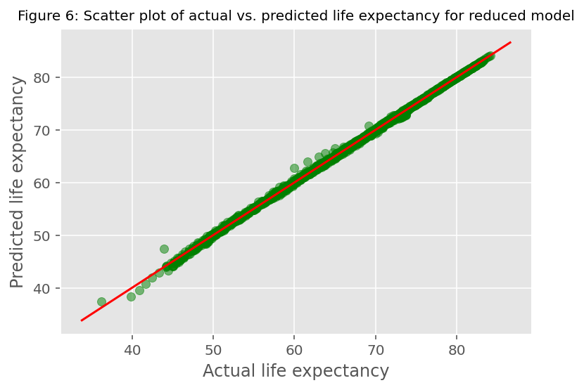

```python
plt.scatter(residuals_reduced['actual'], residuals_reduced['predicted'], alpha=0.5, color="green")
plot_line(axis=plt.gca(), slope=1, intercept=0, c="red")
plt.xlabel('Actual life expectancy')
plt.ylabel('Predicted life expectancy')
plt.title('Figure 6: Scatter plot of actual vs. predicted life expectancy for reduced model', fontsize=10)
plt.show()
```

Just as we did the diagnostic check on the full model, we will be doing one on the reduced model as well.

### Reduced Model Diagnostic Checks

Just like the full model, we are going to create a scatter plot as a function of (predicted life expectancy).

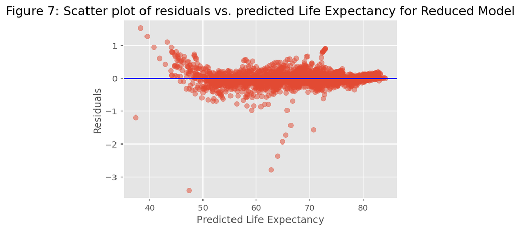

```python
plt.scatter(residuals_reduced['predicted'], residuals_reduced['residual'], alpha=0.5);
plt.axhline(0, c='blue')
plt.xlabel('Predicted Life Expectancy');
plt.ylabel('Residuals')
plt.title('Figure 7: Scatter plot of residuals vs. predicted Life Expectancy for Reduced Model', fontsize=15)
plt.show();
```

Judging form this outcome, we are going to predict that the histogram is also going to be the same, as it is a logical assumption due to the fact that the dataframe of this new model is exactly the same as the full model.

[figure not shown]

```python
plt.hist(residuals, bins=6)
plt.title("figure 8: Histogram of residuals for the Reduced Model")
plt.xlabel('Residual')
plt.ylabel('Frequency')
plt.show()
```

## Critique & Limitations

With the cleaned dataset retrieved from Phase 1, it was quite unexpected that after some statistical modelling we found out that there was an enormous correlation between the dependent variable 'Life Expectancy' and all the other independent variables. This meant that whatever statistical modelling method we apply, we would get an almost one to one correlation between the dependent variable and all the independent variables. As a result of this we are able to conclude that the construction of the categorical variables in the dataset were extremely logical. In this sense, we can be certain that by using this statistical model with these exact categorical variables, we are able to accurately predict the life expectancy of a person in a given country or region with certain bmis etc. with a 99% variance.

## Summary & Conclusions

### Project Summary

In the phase 1 of the project, we needed to preprocess the data in order for it to be 'clean' for our statistical modelling in this phase of the project. We approached this by cleansing the data by removing columns that contained more than 3 digit `NaN` values. After this we dropped all new rows which contained `NaN` values resulting in a clean dataset. We then performed some data exploration and visualisation by plotting these rows and columns into graphs such as histograms, scatterplots and barplots to find some sort of correlation between the different types of variables.

In Phase 2 of the project, we used the clean data to create a statistical model to predict whether or not an average person's life expectancy was based on the numerous categorical variables provided. In order to determine this, we produced a full and reduced model by using the independent variables as the statistical model's formula. We needed to perform an automatic variable selection in order to plug the `String` equation into the `Statsmodels` module. This was performed by a one-hot-encoding process using the `get_dummies()` function in tne `pandas` module. After that we were able to obtain an OLS table where we could determine the R-squared and the p-values. We used the R-squared value to create new dataframe plots. The p-values were used as well for the next stage of backwards feature selection to create the reduced model. After this we performed the diagnostic tests to see whether or not these values complied with the rules.

### Summary of Findings

The initial goal of this project was to predict the life expectancy of people based on different factors surrounding them. Phase 1 has contributed to a simple analysis of this goal as we explored many types of plots to determine whether or not there was a correlation between the categorical and numerical variables. It was concluded in the first phase that there would be different correlations as some variables are independent from other variables. Such was depicted in the BMI vs Life expectancy as we had speculated that there was **NO** correlation between them. We wanted to prove this by introducing statistical modelling in Phase 2.

Phase 2 provided us with more definite answers and foresight via technical analysis of the regression model. The full model given us an R-squared value of 0.9994. This was extremely unexpected as we had conlcuded that there were variables which had nob correlation. No definitive solution was provided as to why this was the case, but we can merely speculate that the original dataset provided was extremely accurate. This might have been the case as extensive research had probably gone into the construction of this dataset due to it being on the `World Health Organisation` website.